# Ketapang Weather Data Exploration

## Initial data exploration

We need to read in the climate data from Ketapang, and perform a couple of calculations to get everything into the right units and format.

```r
# read in the Ketapang climate data
## no data is given the value 9999 in the original data; na.strings converts indicated values to NA (which is what R uses to indicate no data) without any extra steps
## 9999 is no data
## 8888 is no measurable data. not sure how this is different than no data... maybe these should actually be 0?
KTG<-read.csv("/Users/laurenhendricks/Documents/Borneo/KTG_climate-fire/Data/KetapangClimate1986_2016 COPY.csv",header=T,sep=",",na.strings=c("9999","8888"),colClasses = c("character","factor","ddmmyyyy",rep("numeric",7),"factor","numeric","factor") )
# rename the columns into english
colnames(KTG)<-c("station","stationID","date","T_min","T_max","T_avg","humidity","precip","sunshine","wind_speed_knots","wind_dir","wind_maxgust_knots","wind_maxgust_dir")
head(KTG)
```

|  | station | stationID | date | T_min | T_max | T_avg | humidity | precip | sunshine | wind_speed_knots | wind_dir | wind_maxgust_knots | wind_maxgust_dir |
| --- | --- | --- | --- | --- | --- | --- | --- | --- | --- | --- | --- | --- | --- |
| 1 | Stasiun Meteorologi Rahadi Oesman | 96615 | 1986-01-01 | 24.3 | 30.6 | 26.9 | 89 | 9.6 | 4.7 | NA | N | 3 | 70 |
| 2 | Stasiun Meteorologi Rahadi Oesman | 96615 | 1986-01-02 | 24.2 | 30.0 | 26.5 | 90 | 5.8 | 5.2 | NA | N | 2 | 360 |
| 3 | Stasiun Meteorologi Rahadi Oesman | 96615 | 1986-01-03 | 24.4 | 29.2 | 26.2 | 91 | 2.0 | 3.5 | 1 | N | 3 | 320 |
| 4 | Stasiun Meteorologi Rahadi Oesman | 96615 | 1986-01-04 | 23.8 | 29.4 | 26.3 | 91 | 8.6 | 4.3 | 1 | N | 3 | 260 |
| 5 | Stasiun Meteorologi Rahadi Oesman | 96615 | 1986-01-05 | 24.0 | 29.6 | 26.3 | 90 | 5.4 | 4.1 | 2 | N | 3 | 270 |
| 6 | Stasiun Meteorologi Rahadi Oesman | 96615 | 1986-01-06 | 24.0 | 29.6 | 26.4 | 89 | 15.5 | 7.4 | 1 | N | 4 | 330 |

We already have: * Maximum temperature in Celsisus; * Minimum temperature in Celsius; and * Humidity (assuming it is relative humidity).

(Also latitude and elevation of the recording site.)

We also have: * Wind speed, but it needs to be converted from knots to meters per second; * Date, which needs to be converted to the day of the year (aka Julian date); and * Hours of sunshine, which needs to be converted to a percentage.

But first, some quick data exploration.

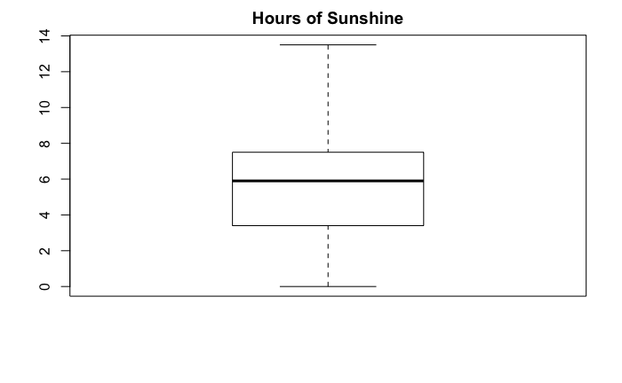

```r
# look at the sunshine data
boxplot(KTG$sunshine,main="Hours of Sunshine")
```

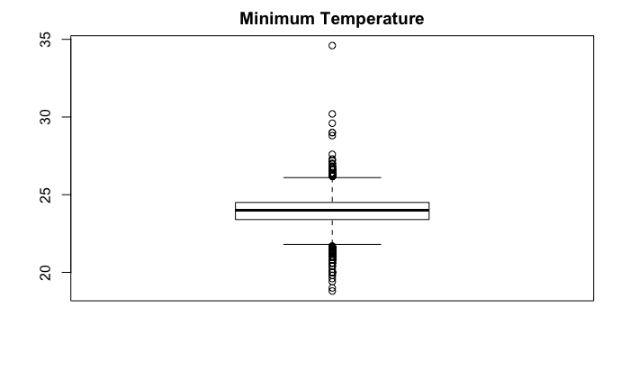

```r
# look at the temperature data
boxplot(KTG$T_min,main="Minimum Temperature")
```

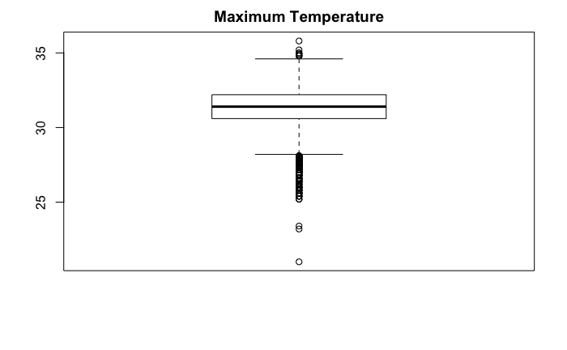

```r
boxplot(KTG$T_max,main="Maximum Temperature")
```

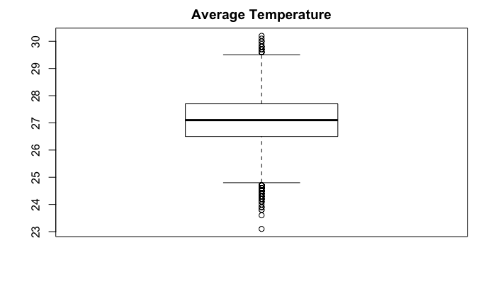

```r
boxplot(KTG$T_avg,main="Average Temperature")
```

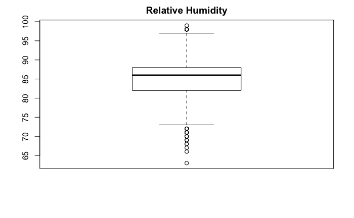

```r
# look at the humidity data
boxplot(KTG$humidity,main="Relative Humidity")
```

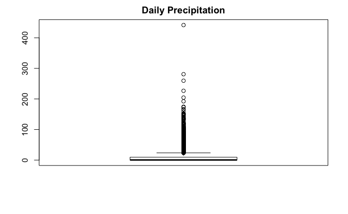

```r
# precip data
boxplot(KTG$precip,main="Daily Precipitation")
```

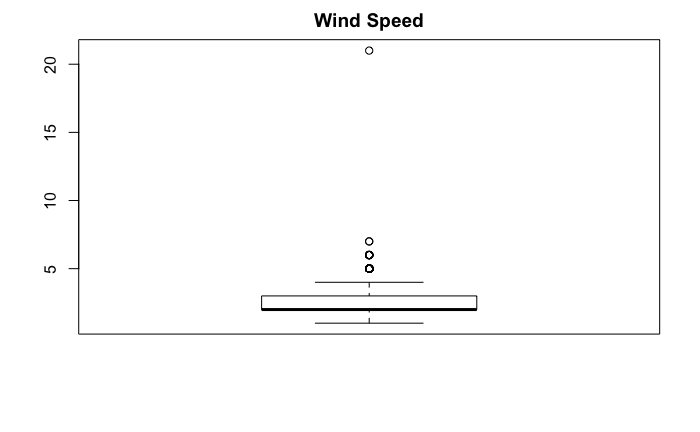

```r
# wind data
boxplot(KTG$wind_speed_knots,main="Wind Speed")
```

Looks like the data is definitely not normally distributed for most of these variables, but since we’re not trying to do any statistical analyses on these it shouldn’t be a problem. We also need to note that there are some clear problems in the data.

## Dealing with NAs and other non-sensical values

Another thing that might need to be dealt with has to do with the windspeed. Windspeed varies with height, so we need to find out the height that the measurement was taken at. There are also a lot of missing values.

Calculate a moving average that we can then use to fill in some of the missing values. This isn’t the ideal approach, but we have to have some value–otherwise the AET for that day will be modeled as 0, which is even less realistic than filling it in with modeled/smoothed data. (Note that for some things, like temperature, a moving average does seem reasonable, but it makes less sense for other things, like wind and precipitation.)

```r
# first count the number of NAs in the columns to identify which need to have a moving average applied
print(paste(sum(is.na(KTG$T_min)),"NAs in T_min"))
```

```
[1] "79 NAs in T_min"
```

```r
print(paste(sum(is.na(KTG$T_max)),"NAs in T_max"))
```

```
[1] "103 NAs in T_max"
```

```r
print(paste(sum(is.na(KTG$T_avg)),"NAs in T_avg"))
```

```
[1] "80 NAs in T_avg"
```

```r
print(paste(sum(is.na(KTG$humidity)),"NAs in humidity"))
```

```
[1] "81 NAs in humidity"
```

```r
print(paste(sum(is.na(KTG$precip)),"NAs in precip"))
```

```
[1] "651 NAs in precip"
```

```r
print(paste(sum(is.na(KTG$sunshine)),"NAs in sunshine hours"))
```

```
[1] "124 NAs in sunshine hours"
```

```r
print(paste(sum(is.na(KTG$wind_speed_knots)),"NAs in wind speed"))
```

```
[1] "1881 NAs in wind speed"
```

```r
# not checking for wind/gust direction because we're not using that anywhere
```

So, looks like we need to use the moving average for every variable of interest, though there are A LOT more missing values for wind than for any of the other measurements.

So, we can use a moving average (mean) to fill in the missing values. Use rollapply() from the zoo package. [Could also check out na.approx() or na.spline() in the zoo package, which could be an interesting comparison. Though, with some initial testing, it seems like it’s not flexible enough? It has issues with NA values. We could also try na.aggregate() which replaces NAs with aggregated values, so we could replace NAs with something like a monthly mean. This is probably not better than a moving average. Yet another option is given by na.locf() which fills in the NAs with the last non-NA value.]

```r
# make a data frame to store the rolling means in
# also have the original data in there NEXT TO THE ROLLING MEAN so it's easier to compare the results
KTG_rollmeans<-data.frame(matrix(nrow=length(KTG$date),ncol=1+(7*2)))    # same number of rows as original, and then 2 columns for each of the 7 variables and have a column for the date
# add in the dates
KTG_rollmeans[,1]<-KTG$date
# set the window
window<-10
KTG_rollmeans[,2]<-KTG$T_min
KTG_rollmeans[,3]<-rollapply(KTG$T_min,window,FUN=mean,fill=NA,partial=1,na.rm=T)
KTG_rollmeans[,4]<-KTG$T_max
KTG_rollmeans[,5]<-rollapply(KTG$T_max,window,FUN=mean,fill=NA,partial=1,na.rm=T)
KTG_rollmeans[,6]<-KTG$T_avg
KTG_rollmeans[,7]<-rollapply(KTG$T_avg,window,FUN=mean,fill=NA,partial=1,na.rm=T)
KTG_rollmeans[,8]<-KTG$humidity
KTG_rollmeans[,9]<-rollapply(KTG$humidity,window,FUN=mean,fill=NA,partial=1,na.rm=T)
KTG_rollmeans[,10]<-KTG$precip
KTG_rollmeans[,11]<-rollapply(KTG$precip,window,FUN=mean,fill=NA,partial=1,na.rm=T)
KTG_rollmeans[,12]<-KTG$sunshine
KTG_rollmeans[,13]<-rollapply(KTG$sunshine,window,FUN=mean,fill=NA,partial=1,na.rm=T)
KTG_rollmeans[,14]<-KTG$wind_speed_knots
KTG_rollmeans[,15]<-rollapply(KTG$wind_speed_knots,window,FUN=mean,fill=NA,partial=1,na.rm=T)
# rename the columns
# will be combo of original names plus noting that it's a rolling mean
names_og<-colnames(KTG)[-(c(1,2,3,11,12,13))]     # get the original names but don't need first two columns (station name & id) or the columns with wind directions. don't need date either because we don't want to append roll mean to that
# also not going to use wind gusts so don't include that
names_new<-paste(names_og,"rollmean10",sep="_")   # add rolling mean to the names
# now a for loop to combine the original and new names in the correct order
names_rollmeans<-NA      # where the new names will be stored
i<-1      # counter that keeps track of which index in the new combined names vector we are at
for(col in 1:length(names_new)){   # col keeps track of index in the vectors we're pulling from
    names_rollmeans[i]<-names_og[col]
    i<-i+1
    names_rollmeans[i]<-names_new[col]
    i<-i+1
}
# add date at the beginning
names_rollmeans<-c("date",names_rollmeans)
# now rename the columns
colnames(KTG_rollmeans)<-names_rollmeans
# print the new number of NAs (though they're acutally NaNs, not NAs, because that is what rollsum() puts out.)
print(paste(sum(is.na(KTG_rollmeans$T_min_rollmean10)),"NAs in T_min_rollmean10"))
```

```
[1] "43 NAs in T_min_rollmean10"
```

```r
print(paste(sum(is.na(KTG_rollmeans$T_max_rollmean10)),"NAs in T_max_rollmean10"))
```

```
[1] "43 NAs in T_max_rollmean10"
```

```r
print(paste(sum(is.na(KTG_rollmeans$T_avg_rollmean10)),"NAs in T_avg_rollmean10"))
```

```
[1] "43 NAs in T_avg_rollmean10"
```

```r
print(paste(sum(is.na(KTG_rollmeans$humidity_rollmean10)),"NAs in humidity_rollmean10"))
```

```
[1] "43 NAs in humidity_rollmean10"
```

```r
print(paste(sum(is.na(KTG_rollmeans$precip_rollmean10)),"NAs in precip_rollmean10"))
```

```
[1] "44 NAs in precip_rollmean10"
```

```r
print(paste(sum(is.na(KTG_rollmeans$sunshine_rollmean10)),"NAs in sunshine_rollmean10"))
```

```
[1] "43 NAs in sunshine_rollmean10"
```

```r
print(paste(sum(is.na(KTG_rollmeans$wind_speed_knots_rollmean10)),"NAs in windspeed_rollmean10"))
```

```
[1] "50 NAs in windspeed_rollmean10"
```

```r
# not checking for wind/gust direction because we're not using that anywhere
```

*NOTE:* There seem to be a few periods where the entire weather station must have been down, because there are no values at all for any of the measurements for those days. Even roll sum can’t deal with that…. unless we use a huge window. Those time periods are: July 2000 and September 1997 (the whole months). To fill all those in, the window would need to be over 30 days… and that’s probably too big! So for the 20 and 21 days in the middle of the month we don’t have any values (because the first and last 5 do have numbers, pulled in from the previous and following months by the roll apply function). Plus, there are several 10+ day periods where no wind measurements were taken: Jan 11-21 1991, April 2-13 1991, April 28-May 8 1991, and Nov 27-Dec 6 1992. (Also note that there are a lot of missing values on either side of those periods, too, but there is at least 1 measurement for every 10 apart from those chunks.) Weirdly, in a lot of these periods, there IS precipitation data but the values are all 0. (So maybe this isn’t accurate data? Checked in the raw data and they really are 0s, not 8888/9999s.) And the 44 NAs/NaNs for precip are in 2015, not in those other long stretches–it’s basically the second half of 2015, with a few days here and there where there is data so it isn’t fully NaNs. Sooo…don’t use those chunks of data!

So, there are some limitations even after filling in the missing values with moving averages… but we have to go ahead and fill in those values anyways.

```r
# now make the replacements!
# figured out how to do this with the toy data in /Users/laurenhendricks/Documents/Borneo/Ketapang_ClimateFire/code/SandboxCode/FillMissingValues.R
KTG$T_min[is.na(KTG$T_min)]<-KTG_rollmeans$T_min_rollmean10[is.na(KTG$T_min)]
KTG$T_max[is.na(KTG$T_max)]<-KTG_rollmeans$T_max_rollmean10[is.na(KTG$T_max)]
KTG$T_avg[is.na(KTG$T_avg)]<-KTG_rollmeans$T_avg_rollmean10[is.na(KTG$T_avg)]
KTG$precip[is.na(KTG$precip)]<-KTG_rollmeans$precip_rollmean10[is.na(KTG$precip)]
KTG$humidity[is.na(KTG$humidity)]<-KTG_rollmeans$humidity_rollmean10[is.na(KTG$humidity)]
KTG$sunshine[is.na(KTG$sunshine)]<-KTG_rollmeans$sunshine_rollmean10[is.na(KTG$sunshine)]
KTG$wind_speed_knots[is.na(KTG$wind_speed_knots)]<-KTG_rollmeans$wind_speed_knots_rollmean10[is.na(KTG$wind_speed_knots)]
# also add in a column that flags where there are NAs filled in with another value in at least one of the other columns
KTG$flag<-NA
KTG$flag[is.na(KTG$T_min)]<-"One or more estimated values"
KTG$flag[is.na(KTG$T_max)]<-"One or more estimated values"
KTG$flag[is.na(KTG$T_avg)]<-"One or more estimated values"
KTG$flag[is.na(KTG$precip)]<-"One or more estimated values"
KTG$flag[is.na(KTG$humidity)]<-"One or more estimated values"
KTG$flag[is.na(KTG$sunshine)]<-"One or more estimated values"
KTG$flag[is.na(KTG$wind_speed_knots)]<-"One or more estimated values"
```

Now check to see if we have the NAs filled in.

```r
# check to see if the number of filled in NAs is less than before
# (ideally it would be 0 but because of the issue noted earlier about the 10+ day stretches of no values we won't ever see 0)
print(paste(sum(is.na(KTG$T_min)),"NAs in T_min"))
```

```
[1] "43 NAs in T_min"
```

```r
print(paste(sum(is.na(KTG$T_max)),"NAs in T_max"))
```

```
[1] "43 NAs in T_max"
```

```r
print(paste(sum(is.na(KTG$T_avg)),"NAs in T_avg"))
```

```
[1] "43 NAs in T_avg"
```

```r
print(paste(sum(is.na(KTG$humidity)),"NAs in humidity"))
```

```
[1] "43 NAs in humidity"
```

```r
print(paste(sum(is.na(KTG$precip)),"NAs in precip"))
```

```
[1] "44 NAs in precip"
```

```r
print(paste(sum(is.na(KTG$sunshine)),"NAs in sunshine hours"))
```

```
[1] "43 NAs in sunshine hours"
```

```r
print(paste(sum(is.na(KTG$wind_speed_knots)),"NAs in wind speed"))
```

```
[1] "50 NAs in wind speed"
```

```r
# check to see if the number of filled in NAs is less than before
# (ideally it would be 0 but because of the issue noted earlier about the 10+ day stretches of no values we won't ever see 0)
print(paste(sum(is.na(KTG_00to15$T_min)),"NAs in T_min"))
```

```
[1] "0 NAs in T_min"
```

```r
print(paste(sum(is.na(KTG_00to15$T_max)),"NAs in T_max"))
```

```
[1] "0 NAs in T_max"
```

```r
print(paste(sum(is.na(KTG_00to15$T_avg)),"NAs in T_avg"))
```

```
[1] "0 NAs in T_avg"
```

```r
print(paste(sum(is.na(KTG_00to15$humidity)),"NAs in humidity"))
```

```
[1] "0 NAs in humidity"
```

```r
print(paste(sum(is.na(KTG_00to15$precip)),"NAs in precip"))
```

```
[1] "0 NAs in precip"
```

```r
print(paste(sum(is.na(KTG_00to15$sunshine)),"NAs in sunshine hours"))
```

```
[1] "0 NAs in sunshine hours"
```

```r
print(paste(sum(is.na(KTG_00to15$wind_speed_knots)),"NAs in wind speed"))
```

```
[1] "0 NAs in wind speed"
```

So now we have a set of data that doesn’t have any NA values, and we can proceed and calcluate the aet and soil water balance.

Now do the same initial data exploration with this data set that is subset of the original set, and has all NA values filled in with a moving average.

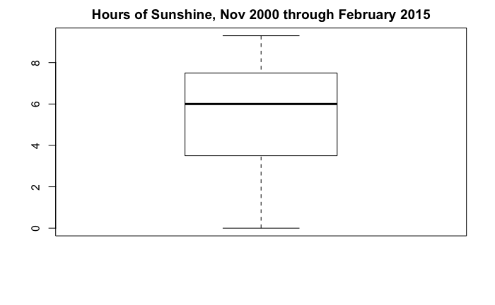

```r
# look at the sunshine data
boxplot(KTG_00to15$sunshine,main="Hours of Sunshine, Nov 2000 through February 2015")
```

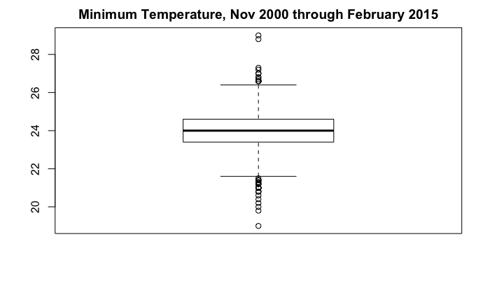

```r
# look at the temperature data
boxplot(KTG_00to15$T_min,main="Minimum Temperature, Nov 2000 through February 2015")
```

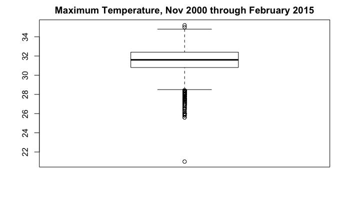

```r
boxplot(KTG_00to15$T_max,main="Maximum Temperature, Nov 2000 through February 2015")
```

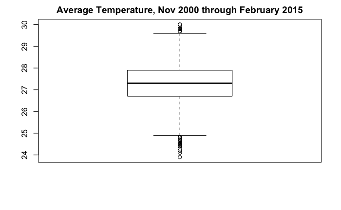

```r
boxplot(KTG_00to15$T_avg,main="Average Temperature, Nov 2000 through February 2015")
```

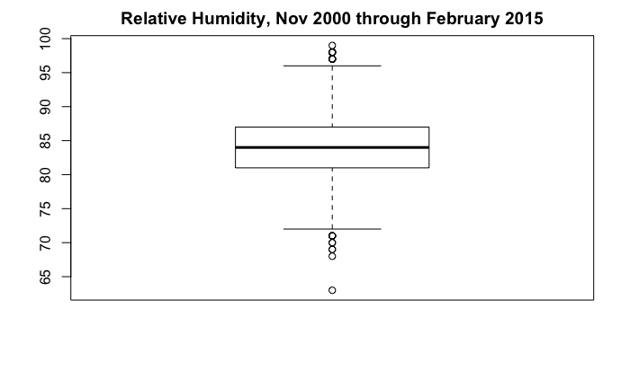

```r
# look at the humidity data
boxplot(KTG_00to15$humidity,main="Relative Humidity, Nov 2000 through February 2015")
```

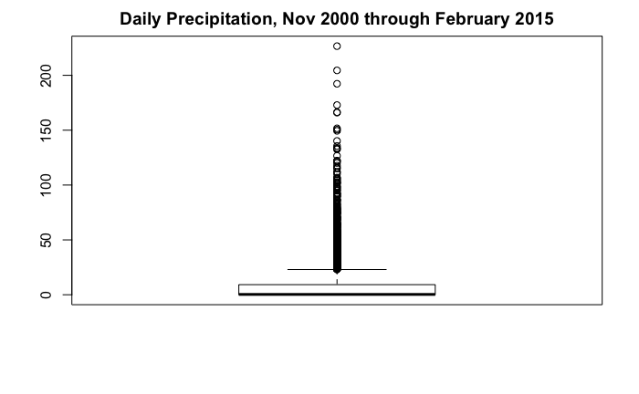

```r
# precip data
boxplot(KTG_00to15$precip,main="Daily Precipitation, Nov 2000 through February 2015")
```

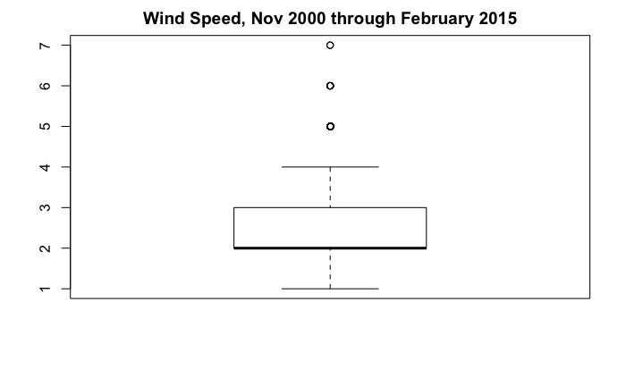

```r
# wind data
boxplot(KTG_00to15$wind_speed_knots,main="Wind Speed, Nov 2000 through February 2015")
```